# Testing Mean

[Nao Mimoto](http://gozips.uakron.edu/~nmimoto/) - [Dept. of Statistics](http://www.uakron.edu/stat/) : [The University of Akron](http://www.uakron.edu)

[Class Web Page](http://gozips.uakron.edu/~nmimoto/477/index.html) – [R resource page](http://gozips.uakron.edu/~nmimoto/R/index.html)

## 1. Is the ture mean 0?

Suppose we have a random sample

```r
  set.seed(235)                    # set seed for RS generation (you don't need to do this)
  mu = sample(c(0,2,1),1)          # mu is randomly drawn from 0, 1, or 2
  Y  = mu + rnorm(100,0,5)         # Y is mu + random noise

  mean(Y)                          # Calculate sample mean
```

```
## [1] 2.016148
```

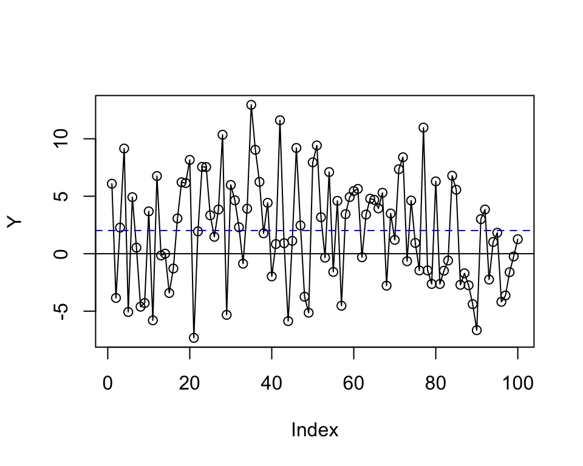

```r
  plot(Y, type="o")                      # type="o" means both line and point
  abline(h=0)                            # add horizontal line at 0
  abline(h=mean(Y), col="blue", lty=2)   # add blue dashed line at sample mean
```

Question is if our ture mean $\mu$ in this plot is $0$ or not.

We know the sample mean $\bar Y$ is not $0$. But is this a random fluctuation? or is this an evidence that we have non-zero true mean?

### Model the data

We can say that above random sample comes from model like this:
$$Y_t = \mu + X_t \hspace15mm
\left\{
\begin{array}{ll}
\mu : &\mbox{ Constant Trend (deterministic) }\\
X_t : &\mbox{ Normal iid noise with mean 0, variance $\sigma$}\\
\end{array} \right.$$

$\mu$ and $\sigma$ are unknown.

### CI for mean $\mu$

- We know how ‘well’ $\bar Y$ estimates $\mu$.
  $$\bar Y \sim N\Big(\mu, \frac{\sigma}{\sqrt n}\Big)$$
- That gives us 95% CI for $\mu$
  $$\bar Y \pm 1.96 \frac{S}{\sqrt n}$$
  Since $\sigma$ is unkown, it is replaced by the sample standard deviation $S$.
- If $0$ is outside of the CI, then we reject $H_0: \mu=0$ with 5% confidence level.

```r
  mean(Y)                      # sample mean of Y
```

```
## [1] 2.016148
```

```r
  sd(Y)                        # sample SD of Y
```

```
## [1] 4.655382
```

```r
  ME = 1.96*sd(Y)/sqrt(100)    # margin of error (width of CI)
  ME
```

```
## [1] 0.9124548
```

```r
  CI.upper = mean(Y) + ME
  CI.lower = mean(Y) - ME
  c(CI.lower, mean(Y), CI.upper)     # show 3 numbers as vector
```

```
## [1] 1.103693 2.016148 2.928603
```

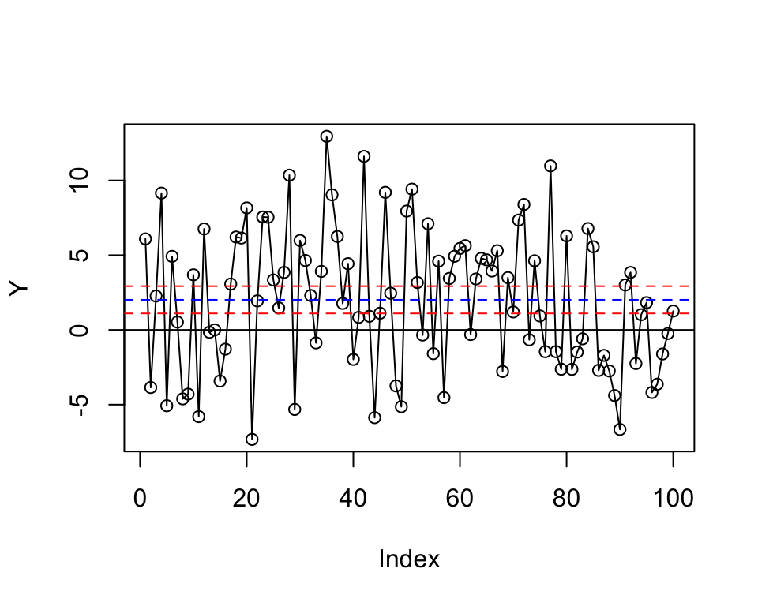

```r
  plot(Y, type="o")                                  # plot Y
  abline(h=0)                                        # draw horizontal line at 0
  abline(h=mean(Y), col="blue", lty=2)               # blue dash line at mean(Y)
  abline(h=c(CI.upper, CI.lower), col="red", lty=2)  # two red dash line at CI.upper and CI.lower
```

**Since $0$ is outside of the 95% CI for $\mu$, with 95% confidence, we conclude that the true mean $\mu$ is not $0$.**

## 2. Time Series Case

We want to do the same when the data shows autocorrelation.

### Model

Suppose we observe $Y_t$, and model it as:
$$Y_t = \mu + X_t \hspace10mm
\left\{
\begin{array}{ll}
\mu : &\mbox{ Constant Trend (deterministic) }\\
X_t : &\mbox{ Stationary Time Series }
\end{array} \right.$$
We assume that $E X_t=0$ and $V(X_t) = \sigma^2$.

- Note that if $X_t$ has autocorrelation, then $Y_t$ is also autocorrelated.
- We will use $\bar Y$ to estimate $\mu$, as usual.

### Expectation of Sample Mean

- Does property of $\bar Y$ changes? Expectation is
  $$E (\bar Y) \hspace3mm = \hspace3mm
  E \Big(\frac{1}{n} \sum_{t=1}^n Y_t\Big)
  \hspace3mm = \hspace3mm \frac{1}{n} \sum_{t=1}^n E (Y_t)$$
- For the mean of one $Y$, we have
  $$E(Y_t)
  \hspace3mm = \hspace3mm E(\mu + X_t)
  \hspace3mm = \hspace3mm \mu + E(X_t)
  \hspace3mm = \hspace3mm \mu + 0
  \hspace3mm = \hspace3mm \mu$$
- So we do have $E(\bar Y) = \mu$ and that’s same as the RS case.
- i.e. $\bar Y$ is still unbiased estimator of $\mu$.

### Variance of Sample Mean

How about the variance of $\bar Y$?

- Since adding a constant does not change the variance,
  $$\begin{aligned}
  V(\bar Y)
  \hspace3mm = \hspace3mm V(\bar Y - \mu )
  \hspace3mm = \hspace3mm
  V \Big( \frac{1}{n} \sum_{i=1}^n (Y_i - \mu) \Big)
  \hspace3mm = \hspace3mm V \Big( \frac{1}{n} \sum_{i=1}^n X_i \Big)
  \hspace3mm = \hspace3mm V ( \bar X )
  \end{aligned}$$
- Now the variance of $\bar X$ can be written as,
  $$V (\bar X)
  \hspace3mm = \hspace3mm V \Big( \frac{1}{n} \sum_{i=1}^n X_i \Big)
  \hspace3mm = \hspace3mm
  \frac{1}{n^2} \, \mbox{Cov}\Big(\sum_{i=1}^n X_i, \, \sum_{j=1}^n X_j \Big)
  \hspace3mm = \hspace3mm
  \frac{1}{n^2} \Big[\mbox{ sum of Cov of all pairs }(X_i, X_j) \Big]$$
- $\Big[\mbox{ Sum of Cov of all pairs }(X_i, X_j) \Big]$ means,
  $$\hspace3mm = \hspace3mm
  \mbox{ Sum of Cov of pairs }
  \left[ \begin{array}{c|cccc}
  & X_1 & X_2 & \cdots & X_n \\
  \hline
  X_1 & \ddots & & \cdots & \\
  X_2 & & \ddots & \cdots & \\
  \vdots & \vdots & \vdots & \ddots & \vdots \\
  X_n & & & \cdots & \\
  \end{array} \right]
  \hspace5mm = \hspace5mm
  \mbox{ Sum of }
  \left[ \begin{array}{cccc}
  \gamma(0) & \gamma(1) & \cdots & \gamma(n-1) \\
  \gamma(-1) & \gamma(0) & \cdots & \gamma(n-2) \\
  \vdots & \vdots &\ddots & \vdots \\
  \gamma(n-1) & \gamma(n-2) & \cdots & \gamma(0) \\
  \end{array} \right]\\$$
  where $\gamma(h)$ is ACVF at lag $h$.
- Conbining, we get
  $$V(\bar Y)
  \hspace3mm = \hspace3mm V(\bar X)
  \hspace3mm = \hspace3mm \frac{1}{n^2} \sum_{h=-n}^n (n-|h|) \gamma(h)
  \hspace3mm = \hspace3mm
  \frac{1}{n^2} \sum_{h=-n}^n (n-|h|) \gamma(h)
  \hspace3mm = \hspace3mm
  \frac{1}{n} \sum_{h=-n}^n \Big(1 -\frac{|h|}{n}\Big) \gamma(h).$$

**The variance of sample mean is different under the presence of autocorrelation.**

- Note that if $X_t$ were iid as in the first section, then $\gamma(0)=1$, and $\gamma(h)=0$ for all $h \ne 0$. Above formula reduces to
  $$V (\bar X)
  = \frac{1}{n} \Big(1 -\frac{|0|}{n}\Big) \gamma(0)
  \hspace3mm = \hspace3mm \frac{\sigma^2}{n}$$

### CI for $\mu$ When $Y_t$ is TS

So we have
$$V (\bar Y) = \frac{\nu^2}{n} \hspace5mm
\mbox{ where } \hspace5mm \nu^2 = \sum_{h=-n}^n \Big(1 -\frac{|h|}{n}\Big) \gamma(h).$$
That means approximately,
$$\bar Y \sim N\Big(\mu , \frac{\nu}{\sqrt n} \Big).$$
Then the confidence interval for $\mu$ is
$$\bar Y \pm 1.96 \sqrt{\frac{ \nu^2 }{n}}$$

- In practice, we don’t know the true value of $\gamma(h)$, so we need to use the sample version $\hat \gamma(h)$. (sample ACVF instead of theoretical ACVF)
  $$\hat \nu^2 = \sum_{h=-\sqrt n}^{\sqrt n} \Big(1 -\frac{|h|}{n}\Big) \hat \gamma(h).$$
- Also, we can’t really use $\hat \gamma(h)$ with $h$ close to $n$. So sum goes from $-\sqrt{n}$ to $\sqrt{n}$ instead.
- Finally, modify the sum to:
  $$\hat \nu^2 = \sum_{h=-\sqrt n}^{\sqrt n} \Big(1 -\frac{|h|}{n}\Big) \hat \gamma(h)
  \hspace3mm = \hspace3mm
  \gamma(0) + 2 \sum_{h=1}^{\sqrt n} \Big(1 -\frac{|h|}{n}\Big) \hat \gamma(h).$$

### Example: AR(1) data

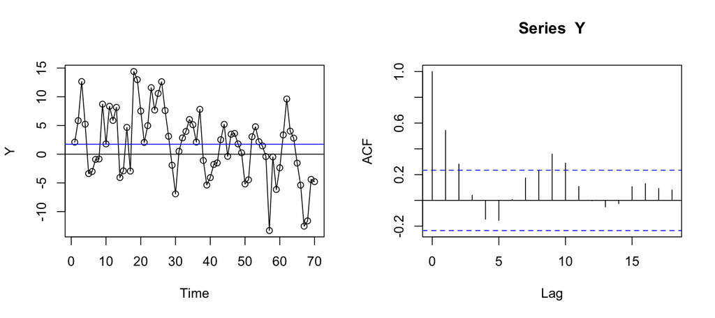

```r
  set.seed(1352)
  mu = sample(c(0,1,2), 1)
  X  = arima.sim(n=70, list(ar = c(.7) ), sd=5 )     #
  Y  = mu + X

  layout(matrix(1:2, 1, 2))             # plot side by side
  plot(Y, type="o")                     # plot Y
  abline(h=0)                           # draw at 0
  abline(h=mean(Y), col="blue")         # draw blue line at sample mean
  acf(Y)                                # plot acf as 2nd plot
```

Because of the presence of significant ACF at lag 1, we need to use the new formula for CI.

```r
  #--- CI for ture mean using ACVF ---
  n = length(Y)  # This is n
  n              # see what's inside
```

```
## [1] 70
```

```r
  Ga <- acf(Y, type="covariance", plot=FALSE)   # calculate ACVF values without plotting
  str(Ga)                                       # See the structure inside Ga
```

```
## List of 6
##  $ acf   : num [1:19, 1, 1] 35.06 19.04 9.88 1.38 -5.13 ...
##  $ type  : chr "covariance"
##  $ n.used: int 70
##  $ lag   : num [1:19, 1, 1] 0 1 2 3 4 5 6 7 8 9 ...
##  $ series: chr "Y"
##  $ snames: NULL
##  - attr(*, "class")= chr "acf"
```

```r
  Ga.hat = Ga$acf                               # extract only "acf" part (it's actually ACVF)

  sum.limit = floor( sqrt(n) )                  # make sqrt(n) into integer (for later use)
  nu.sq <- Ga.hat[1] + 2*sum( (1-(1:sum.limit)/n) * Ga.hat[2:(sum.limit+1)] )
                                                #- Ga.hat[1] is ACVF at lag 0
  mean(Y)
```

```
## [1] 1.732918
```

```r
  sqrt(nu.sq/n)        # Margin of Error accounting for ACVF
```

```
## [1] 1.197743
```

```r
  sqrt(var(Y)/n)       # Margin of Error if we treat Y as Rand Sam (Wrong)
```

```
## [1] 0.7127774
```

```r
  CI.u <- mean(Y) + 1.96*sqrt(nu.sq/n)
  CI.l <- mean(Y) - 1.96*sqrt(nu.sq/n)
  c(CI.l, mean(Y), CI.u)                       # show CI.l, mean(Y), CI.u as vector
```

```
## [1] -0.6146584  1.7329183  4.0804951
```

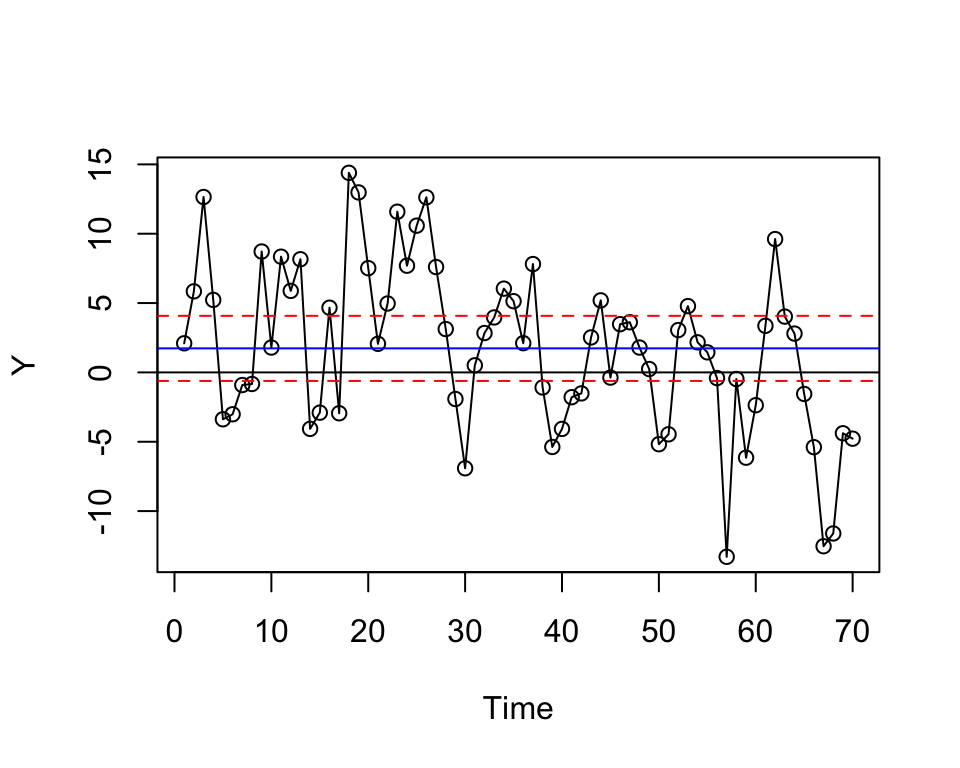

```r
  plot(Y, type="o")
  abline(h=0)                                  # add black line at 0
  abline(h=mean(Y), col="blue")                # add blue horizontal line at mean(Y)
  abline(h=c(CI.u, CI.l), col="red", lty=2)    # add red dash lines at CI
```

**Because 95% CI includes $0$, we can not reject the null hypothesis that the true mean of $Y$ is $0$.**

Note that if we used the RS version of the formula, we would have rejected.

### Example: Color data

```r
  acf1 <- acf
  library(TSA)    # load package TSA
```

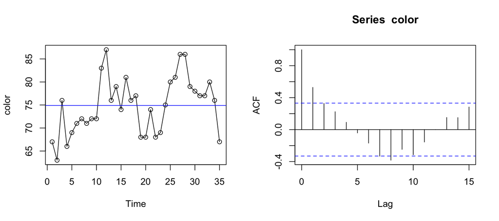

```r
  acf <- acf1

  data(color)

  layout(matrix(1:2, 1, 2))             # plot side by side
  plot(color, type="o")                 # plot
  abline(h=0)                           # draw at 0
  abline(h=mean(color), col="blue")     # draw blue line at sample mean
  acf(color)
```

This time, let’s just get CI for the ture mean without testing to see if it is different from 0.

Note that I’m using the exact copy of the code used in the last section.

```r
  Y = color                             # So that I can reuse the above code without changing each Y

  #--- CI for ture mean using ACVF ---
  n = length(Y)  # This is n
  n              # see what's inside
```

```
## [1] 35
```

```r
  Ga <- acf(Y, type="covariance", plot=FALSE)   # calculate ACVF values without plotting
  str(Ga)                                       # See the structure inside Ga
```

```
## List of 6
##  $ acf   : num [1:16, 1, 1] 36.04 19.04 11.79 8.08 3.31 ...
##  $ type  : chr "covariance"
##  $ n.used: int 35
##  $ lag   : num [1:16, 1, 1] 0 1 2 3 4 5 6 7 8 9 ...
##  $ series: chr "Y"
##  $ snames: NULL
##  - attr(*, "class")= chr "acf"
```

```r
  Ga.hat = Ga$acf                               # extract only "acf" part (it's actually ACVF)

  sum.limit = floor( sqrt(n) )                  # make sqrt(n) into integer (for later use)
  nu.sq <- Ga.hat[1] + 2*sum( (1-(1:sum.limit)/n) * Ga.hat[2:(sum.limit+1)] )
                                                #- Ga.hat[1] is ACVF at lag 0
  mean(Y)
```

```
## [1] 74.88571
```

```r
  sqrt(nu.sq/n)        # Margin of Error accounting for ACVF
```

```
## [1] 1.799286
```

```r
  sqrt(var(Y)/n)       # Margin of Error if we treat Y as Rand Sam (Wrong)
```

```
## [1] 1.029621
```

```r
  CI.u <- mean(Y) + 1.96*sqrt(nu.sq/n)
  CI.l <- mean(Y) - 1.96*sqrt(nu.sq/n)
  c(CI.l, mean(Y), CI.u)                       # show CI.l, mean(Y), CI.u as vector
```

```
## [1] 71.35911 74.88571 78.41232
```

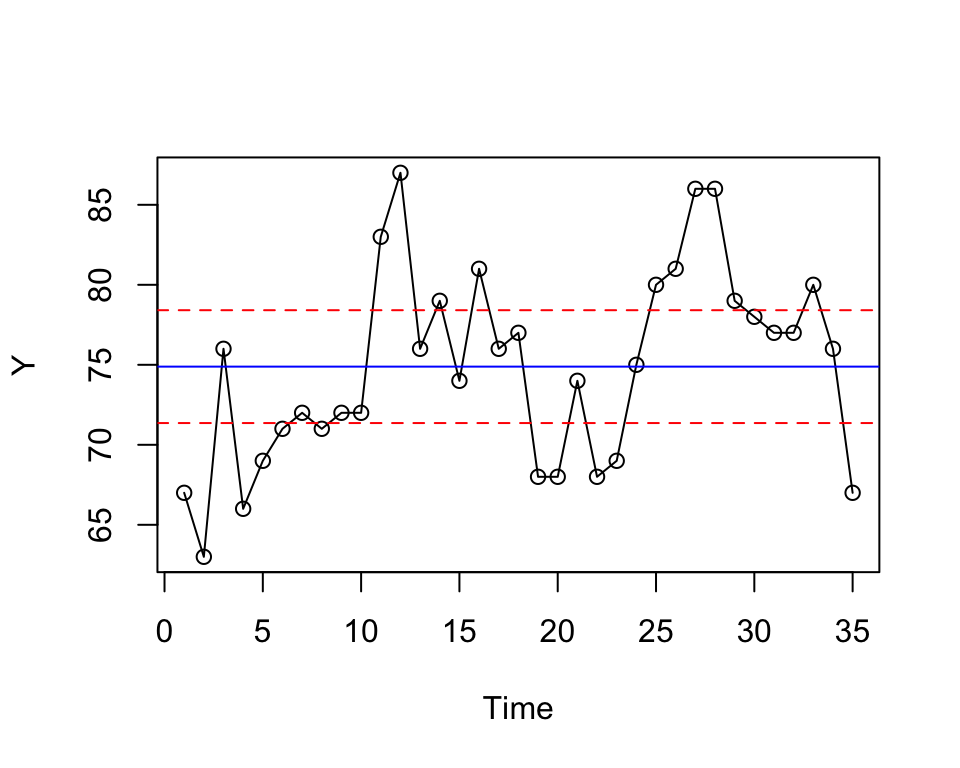

```r
  plot(Y, type="o")
  abline(h=0)                                  # add black line at 0
  abline(h=mean(Y), col="blue")                # add blue horizontal line at mean(Y)
  abline(h=c(CI.u, CI.l), col="red", lty=2)    # add red dash lines at CI
```

## 3. Summary

- To test if the true mean is $0$ or not, we must construct CI for $\mu$, and see if $0$ is inside the CI or not.
- For autocorrelated data, variance of the sample mean is bigger than the random sample case. We must estimate the sample mean variance by summing up sample ACVF.